# Exploratory Analysis

## Weather Conditions on Mars Data Analysis

### Authors

Sofia Alukal (salukal@uw.edu), Evan Chang (evanc9@uw.edu), Sara Duan (saraduan@uw.edu), Emily Hao (haoemily@uw.edu)

### Date

Winter 2023

### Abstract

Our project’s main question will focus on analyzing the weather conditions on Mars. This question is important because understanding the weather conditions on a different planet such as Mars will give us more insight into the potential of life in places other than Earth. To address this question, we will be analyzing how the minimum and maximum temperatures, pressure, and atmospheric opacity trends over time since Curiosity landed on Mars in order to draw a conclusion on what the weather looks like on Mars.

### Keywords

Mars, weather_mars, weather, Curiosity, rover

### Introduction

Our project will be analyzing a dataset containing the solar longitude, minimum and maximum temperatures, pressure, and atmospheric opacity of Mars over Martian and Earth times. To answer our main question of what Mars’ weather conditions are like, we will be more specifically investigating:

1. How do temperatures vary on each sol (Martian day)?
2. Is there any evidence of different seasons on Mars?
3. How does the solar longitude determine the weather conditions on Mars?

There has been much debate and exploration over the question of if life is possible on Mars over the years. While this analysis will not necessarily prove if this assertion is true, analyzing the weather conditions on Mars is an important and vital step to possibly answering this question. Thus, we decided to chose to focus on these questions specifically because we found it fascinating to learn and share about the weather conditions on another planet like Mars. Being able to understand Mars’ weather conditions could also bring insight to how we understand our own weather conditions on Earth. We were also curious to see if Mars’ weather conditions had any similiarties and differences compared to the Earth we live on. Our goal is to hopefully help others become fascinated by the notion of an extraterrestial planet like Mars having weather and different seasons

### Related Work

Our research topic is on Mars’ weather conditions:

1. [Mars Weather Data Analysis Using Machine Learning Techniques](https://doi.org/10.1007/s12145-021-00643-0)
   - This paper also analyzes Mars’ weather data by using machine learning models, claiming that Mars’ climate makes it an ideal candidate for space colonization. It begins by describing how the similar axial tilt creates similar seasons on Mars compared to Earth before conducting tests and creating data visualizations using novel machine learning algorithms. From these tests, they conclude that their machine learning programs produce better models of analysis compared to traditional observational research.
2. [The Current Weather and Climate of Mars: 12 years of Atmospheric Monitoring By the Planetary Fourier Spectrometer on Mars Express](https://doi.org/10.1016/j.icarus.2019.113406)
   - This research uses thermal-infrared spectra to retrieve atmospheric temperature profiles on mars. Their collected dataset covers season, latitude, longitude, and local time, observing Mars’ global atmosphere and weather conditions. However, they focus their research more on daily dust cycles and the presence of water vapor in atmospheres, creating data visualizations of ice opacity and dust storms.
3. [Multiyear mars Orbiter Camera (MOC) Observations of Repeated Martian Weather Phenomena During the Northern Summer Season](https://doi.org/10.1029/2001JE001588)
   - This research project also analyzes Mars’ weather conditions; however, they focus their research more on Mars’ interannual variations in its northern summer seasonal climate. By analzying dust storms and cloud patterns on Mars, they observe Mars’ northern summer and southern winter seasons using the Mars Global Surveyor Mars Orbiter Camera (MOC), drawing the conclusion that clouds, dust storms, and dust devils reoccur annually at nearly the same locations and time of year.

### The Dataset

Where did you find the data? Please include a link to the data source

- We found our dataset on [The Puddings GitHub Data repository](https://github.com/the-pudding/data/tree/master/mars-weather). After researching a lot of different data sets we all found that this one had a really interesting topic and unique data.

Who collected the data?

- This data was collected by Rover Environmental Monitoring Station (REMS) on-board the Curiosity Rover, and it was published by NASA’s Mars Science Laboratory.

How was the data collected or generated?

- This data was collected by the REMS on the Curiosity Rover. REMS has many different monitors and sensors to collect pressure, windspeed, temperature, humidity and much more. The sensors are booms on the rover’s mast.

Why was the data collected?

- The curiosity rover is there to gather intell and data on Mars’s atmosphere and environment. It has collected data longterm, the same way many other rovers have. The more we learn about other planets and their science, the more we will ultimately understand about our own.

How many observations (rows) are in your data?

- There are 1895 rows in our data. Because there were so many observations, we were thinking of maybe analyzing the last five years as opposed to the last ten.

How many features (columns) are in the data?

- There are 10 features in the data.

What, if any, ethical questions or questions of power do you need to consider when working with this data?

- If there were species or animals on Mars, we would consider whether the Curiosity rover is damaging ecosystems or environments. However, we researched what Mars’s environment contains, and according to Nasa the planet is completely inhospitable.

What are possible limitations or problems with this data? (at least 200 words)

- This dataset’s main limitation is that it does not always specify and quantify its necessary values. For instance, the atmo_opacity column only specifies “Sunny”. This is not a very quantifiable value as it does not specify the degree to which the opacity of the atmosphere has changed that day. Because most, if not all, values in this column are “Sunny,” this column creates some difficulties when trying to draw a viable conclusion on how atmospheric opacity helps contribute to the weather conditions found on Mars. Additionally, the wind_speed column indicates “NaN” through many rows, if not all rows. The dataset has addressed this limitation, saying that the “wind speed data has not be transmitted to Earth since Sol 1485.” This leaves us with a large limitation because it is not possible to analyze the wind speeds in Mars as there is no valid number to analyze on any of Mars’ days. This dataset, although has mostly valid, comprehensive data that is ideal for analysis, also contains columns that are almost unusable due to its vagueness or unquantifiabliity. Finally, one last major limitation is the Data Disclaimer from The Centro de Astrobiología, which states how the rover does not take measurements continuously or at the same time everyday. Moreover, the data taken by the Rover is dependent on the rover’s position, temperature, orientation, shade, dust depositions on the rover, etc. These two major limitations may create large variations when analyzing this data set.
- In order for this data set to have meaningful analysis, there has to be a comparison of earth’s temperatures (in an equivalent location) with the Mars data set; without a control group or base comparison, most of the temperature data doesn’t signify. Another complication with this dataset is the lack of specificity regarding the Curiosity rover’s location; we know what general hemisphere it is located in, as well as the Mars-Sun angle, but that still leaves much room for misinterpretation or improper analysis. Part of the reason there are inconsistencies with this data set is due to many of the units being Earth’s standards. For example, Earth has a more circular orbit compared to Mars’s elliptical orbit. This means that at different times of the year, Mars is further or closer to the Sun due to its elliptical orbit (and not just the axis tilt); however this doesn’t appear to be taken into consideration in the data set. Another inconsistency is the axis of Mars (25 degrees) compared to Earth (23.4 degrees), although slight they can drastically affect the temperature of the most polar hemispheres of the planets.

### Implications

An analysis of this dataset would provide a more comprehensive view on the environments and conditions on Mars, which can help technologists, designers, and policymakers determine the amount of funding that is input into space research programs, such as NASA. A comprehensive view of this has implications beyond just simply finding out the weather on Mars—it can allow for a comparison between the conditions faced in Earth and the conditions faced in Mars. Due to the deteriorating health of Earth today from greenhouse gases, deforestation, pollution, etc…, a consideration for a more viable option for human habitation may be necessary for the future of human kind. Although an analysis of this specific dataset is not nearly enough for a consideration for the possibility of human habitation on Mars, designers can use this concise method of comparing the weathers between Earth and Mars and expand further upon them, and technologists may want to update and implement more relevant technologies for space research, perhaps including an updated design for future rovers to collect more data more efficiently. Scientists and world leaders may benefit from a proper analysis of the conditions of Mars if Earth is no longer a viable option for human life.

### Limitations & Challenges

Analyzing data about Mars’ weather conditions creates some major challenges and limitations. For one, it is incredibly expensive to collect this data, as space research can cost billions of dollars. Because this process also takes a long time since we have to wait years to collect weather data in order to draw conclusions about seasons and cycles, this can create a less comprehensive data analysis with what we currently are able to analyze. Moreover, as previously mentioned, Curiousity collects all the data from the southern hemisphere, which may create some ambiguity when trying to extrapolate an interpretation about Mars’ entire global weather conditions. Finally, as addressed in the limitations portion of the dataset, one last challenge concerns the accuracy and variation of the data. It’s already expensive to have one rover collect data as is, but it creates questions about how accurate the data could be since Curiousity is only able to collect information from one location, instead of averaging out the same data points from maybe different rovers from different locations in the same general area. This would help to reduce the variation in the dataset caused by the rover’s inconsistencies, such as taking measurements during different times of the day, or dust deposition.

### Summary Information

Our analysis revealed that over the 1977 sols, or Martian days observed, the maximum temperature difference is 85 degrees Celsius which occurred during month 7, while the minimum temperature difference is 45 degrees Celsius, which occurred during month 3. The highest temperature recorded during one Martian day was 11 degrees Celsius, which was observed during month 7, while the lowest temperature observed is -90 degrees, which occurred during month 3. Finally the average atmospheric pressure on Mars overall is 841.0664167 Pa, with month 9 having the highest pressure of 925 Pa and with month 5 having the lowest pressure of 727 Pa.

### Table: Aggregate Mars Weather Data by Month

| Month | Average Minimum Temperature °C | Average Maximum Temperature °C | Average Temperature Difference °C | Average Atmospheric Pressure (Pa) |
| --- | --- | --- | --- | --- |
| 1 | -77.2 | -15.4 | 61.7 | 862.5 |
| 2 | -79.9 | -23.4 | 56.5 | 889.5 |
| 3 | -83.3 | -27.7 | 55.6 | 877.3 |
| 4 | -82.7 | -25.3 | 57.5 | 806.3 |
| 5 | -79.3 | -16.7 | 62.6 | 748.6 |
| 6 | -75.3 | -7.8 | 67.5 | 745.1 |
| 7 | -72.3 | 0.0 | 72.3 | 795.1 |
| 8 | -68.4 | -0.6 | 67.8 | 873.8 |
| 9 | -69.2 | -2.2 | 66.9 | 913.3 |
| 10 | -72.0 | -3.3 | 68.7 | 887.3 |
| 11 | -72.0 | -4.2 | 67.8 | 857.0 |
| 12 | -74.5 | -7.9 | 66.5 | 842.2 |

This table shows aggregate information of mars’ average weather conditions by each of the twelve months, ordered numerically. We thought that this grouping was interesting to view how the average minimum and maximum temperature (measured in Celsius), as well as pressure varies, or doesn’t vary month by month. By finding the average temperature differences between the average minimum and maximum temperatures, we were able to see that temperature on Mars varies extensively each day throughout the 12 month cycle. Some other insights, is how average pressure on Mars varies somewhat more during months 5-9 compared to the rest of the months.

### Chart 1

[figure not shown]

This chart demonstrates the differences between minimum and maximum temperatures over the course of a year. The reason I chose to do a line chart is because it can clearly demonstrate the differences between the two extremes of the temperatures. It also can help to show viewers the overall changes in temperature over the course of a year. The question I hoped to answer with this kind of chart was “Does the difference in minimum and maximum temperatures change over the course of the year?” Many different charts could demonstrate this, I was considering a scatter plot, but ultimately felt that the continuous motions of temperature and seasons would be best visualized by a linear graph.

The chart shows that there is an extreme difference between the minimum and maximum temperatures of the day. Based on this one year, it seems that minimum temperature stays relatively close to a baseline temperature of -75°C +- 10°C. However, this is a stark contrast from the maximum temperature which ranges from approximately 5°C to -30°C. The average demonstrates the stark contrast between the hottest and coldest temperatures of the day.

### Chart 2

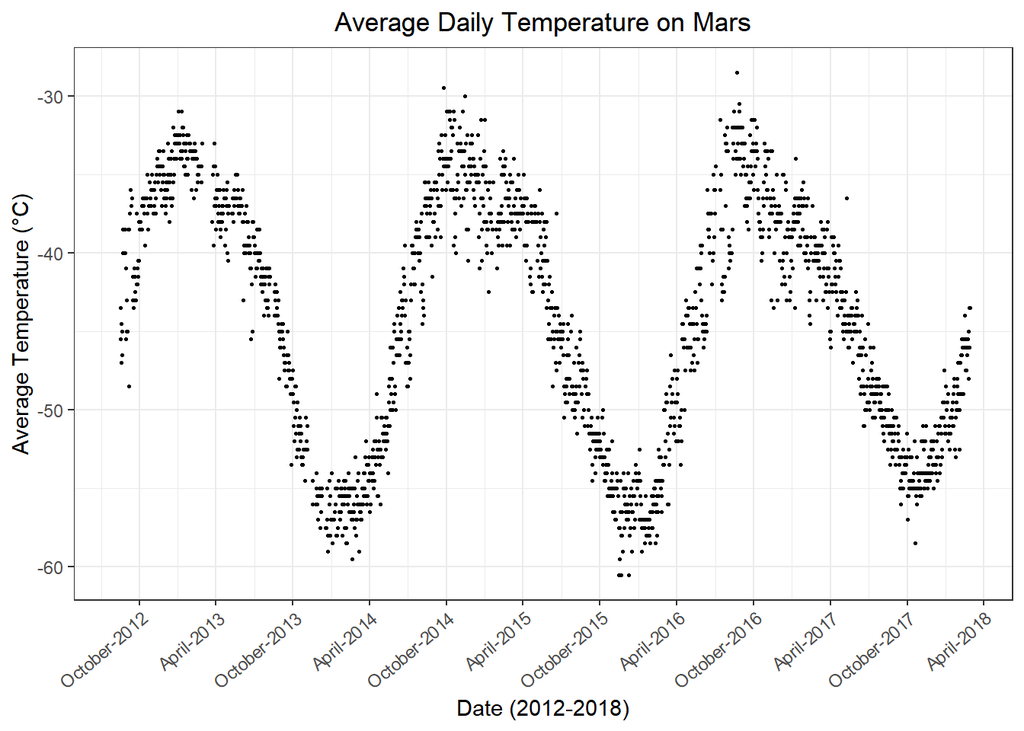

Understanding the seasonal temperature changes on Mars is important for several reasons. First, it can provide insight into the planet’s climate and weather patterns, which can help scientists better understand the planet’s geology and potential habitability. It can also help assist in the planning of future missions to Mars, as extreme temperature changes can affect spacecraft and equipment and a general understanding of the conditions on Mars is crucial. Finally, studying the seasonal temperature changes on Mars can provide important information for understanding its relationship and similarities with Earth. With an increasingly deteriorating condition of the atmosphere and land on Earth, it is helpful to have an understanding of alternate human habitable planets.

### Chart 3

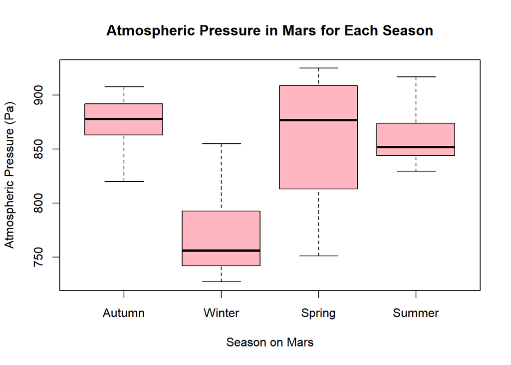

This chart illustrates four boxplots that show the atmospheric pressure on Mars for each of the planet’s seasons. Each boxplot represents a single season, and the four seasons included are spring, summer, fall, and winter.

The horizontal axis of each boxplot represents each respective season, which are divided generally by Autumnal Equinox (when the solar longitude is equal to 0), Winter Solstice (when the solar longitude is equal to 90), Spring Equinox (when the solar longitude is equal to 180), and Summer Solstice (when the solar longitude is equal to 270). The solar longitude is the Mars-Sun angle, measured from the Northern Hemisphere.

The top and bottom edges of each boxplot indicate the maximum and minimum pressure values recorded during the season. The box itself represents the interquartile range (IQR), or the middle 50% of the pressure data for that season. The median pressure is marked by a horizontal line inside the box.

In general, the boxplots show that Mars experiences significantly less atmospheric pressure in winter than in the other seasons, as winter’s median is much smaller. The season of spring seems to range a lot in atmospheric pressure, with the largest IQR. Autumn and summer show the most similar atmospheric pressure, each with a small overall range in the same area. Overall, the series of boxplots provides a clear visual representation of the seasonal patterns of atmospheric pressure on Mars and the significant pressure variations that occur throughout the year.